# Concepts on the Open Economy

## Nominal and real exchange rates

For concreteness, assume that we are looking at the euro/dollar exchange rate (€/$).

On November 19, 2018: **1 euro = 1.146 dollar**, or **1 dollar = 0.873 euro**.

Let us denote by $E$ the number of euro per dollar:
$$E =0.873 \text{ € / dollar}.$$
If I have a price in dollars, how much is it in euros? $E \cdot P$.

$P$ is the price in dollars, and $P^{*}$ is the price in euros. What is the reakl exchange rate: the price of U.S. goods in terms of European goods is:
$$\epsilon=\frac{E \cdot P}{P^{*}}.$$

For example, I wanted to buy a new macbook pro: - $ 2399 net of taxes, $ 2,650.90 inclusive in the U.S. - $ 2799 euros, including 467 euros of VAT.

What is the “real exchange rate” in this case? It is given by the price of Macbook pro bought in the U.S. in euros, which is $E \cdot P$: 0.873*2650.90 = 2314.2 euros. So the price is:
$$\epsilon = \frac{2314.2}{2799}=0.827$$
So it’s 17% cheaper to buy myMac Book Pro in the united States

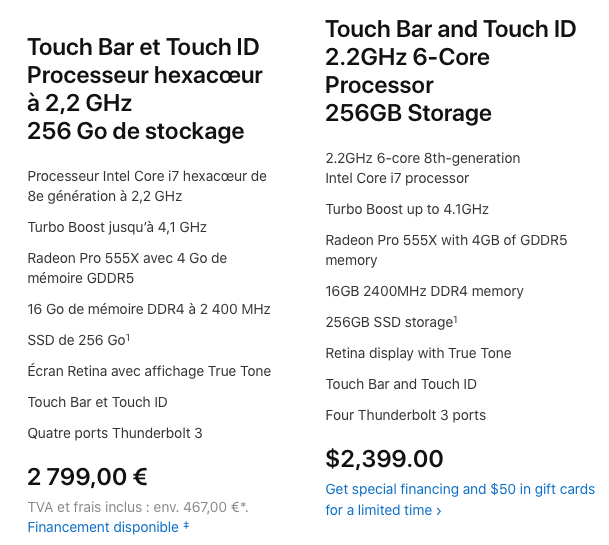

Same Macbook on U.S. and France Stores

The big mac index is that I have the price of big macs

## Different levels of tradability

The big mac index: housing is something that is clearly more expensive in Los Angeles, for instance

Why is there no arbitrage? Different keyboards, warranties, trade costs. For tradable goods: differences are rarely larger than 30%, or they would be arbitraged away.

Now in the last days, the dollar to euro exchange rate has moved substantially, implying substantial movements in the relative price of tradables.

There are two different cases: in the long run, nominal exchange rates drive real exchange rates.

In response to real exchange rate shocks: either price levels or nominal exchange rates can adjust. In inflation targeting: it’s the nominal exchange rate that adjusts (and interest rates rise progressively, which leads to UIP)

## Different levels of openness

In principle, nothing is different between a city taht is open, and a country that is open (except for where fiscal policy is actually decided, as well as whether countries have independant monetary policies)

# Depreciation, the Trade Balance, and Output

Imagine that the government can take a policy measure that leads to a depreciation of the exchange rate. This is an important topic right now, most notablu with respect to the issue of Trump, for example

Does a depreciation improve the trade balance? The Marshall-Lerner condition. If we start from the definition of net exports:
$$NX=X-\frac{IM}{\epsilon}$$

Replacing $X$ and $IM$ by their expressions:
$$NX=X\left(Y^{*},\epsilon\right)-\frac{IM(Y,\epsilon)}{\epsilon}$$

The Marshall-Lerner condition is the condition under which a real depreciation, a decrease in the real exchange rate leads to an improvement in the trade balance. Indeed:
$$\frac{\partial IM}{\partial\epsilon}>0,\quad\frac{\partial X}{\partial\epsilon}<0,\quad\frac{\partial1/\epsilon}{\partial\epsilon}=-\frac{1}{\epsilon^{2}}<0$$

Therefore, with a real depreciation, or a fall in $\epsilon(d\epsilon<0)$, imports are lower as goods are more expensive abroad, exports increase as goods are cheaper abroad, but the valuation effect means that initially at least, the trade balance deteriorates.

The Marshall-Lerner condition considers a case where trade is initially balanced, so that:
$$IM=\epsilon X$$

Starting from: $NX=X-\frac{IM}{\epsilon}$ and first differentiating this function with respect to $\epsilon$:

$$\begin{aligned}
\frac{dNX}{d\epsilon} =\frac{dX}{d\epsilon}-\frac{1}{\epsilon}\frac{dIM}{d\epsilon}-IM\frac{d(1/\epsilon)}{d\epsilon}
\frac{dNX}{d\epsilon} =\frac{dX}{d\epsilon}-\frac{1}{\epsilon}\frac{dIM}{d\epsilon}+IM\frac{1}{\epsilon^{2}}
\end{aligned}$$

Therefore, if the real exchange rate changes from $\epsilon$ to $\epsilon+d\epsilon$, then the change $dNX$ is given by (just multiply the previous expression by the small increment $d\epsilon$):

$$dNX=dX-\frac{dIM}{\epsilon}+\frac{IM}{\epsilon^{2}}d\epsilon$$

Therefore:
$$\frac{dNX}{X}=\frac{dX}{X}-\frac{dIM}{\epsilon X}+\frac{IM}{\epsilon X}\frac{d\epsilon}{\epsilon}$$

Using that $IM=\epsilon X$, we get:
$$\boxed{\frac{dNX}{X}=\frac{dX}{X}-\frac{dIM}{IM}+\frac{d\epsilon}{\epsilon}}.$$

For example, if a 1% depreciation leads to a proportional increase in exports of 0.9%, a proportional decrease in imports of 0.8%, then in total we get thet the trade balance changes by -1+0.9+0.8=0.7%.

**Combining Exchange Rate and Fiscal Policies.** An increase in net exports, coming about from a depreciation of the real exchange rate, will bring an improvement in the trade balance. Through the multiplier effect, there will be multiple rounds of additional spending. In order to decrease the trade deficit, without bringing about too much overheating, one may want to decrease government spending at the same time, in order to bring back GDP at potential.

**The dynamics of net exports: the J-curve.** In practice, the negative effect on net exports is immediate. The positive effects on export and import volumes only come about gradually.

# The Keynesian Cross in the Open Economy

In lectures 7, 8, 9 and 10, we made a very strong assumption: we assumed that the economy was closed. This assumption can only be justified when thinking about the world as a whole. However, the relevance of the theory is then considerably diminished, because fiscal policy such as government spending or the tax and transfer system, are largely decided at the national level. When the economy is open, the fiscal multiplier is lower because some of the increased demand is addressed to foreign products. J.M. Keynes describes this phenomenon in *The General Theory of Employment, Interest and Money* as follows:

> In an open system with foreign-trade relations, some part of the multiplier of the increased investment will accrue to the benefit of employment in foreign countries, since a proportion of the increased consumption will diminish our own country’s favourable foreign balance; so that, if we consider only the effect on domestic employment as distinct from world employment, we must diminish the full figure of the multiplier. On the other hand our own country may recover a portion of this leakage through favourable repercussions due to the action of the multiplier in the foreign country in increasing its economic activity.

During this lecture, we shall extend the goods market model of lecture 7 to allow for the importing and exporting of goods, as well as the potential for a deficit or a surplus in the trade balance. We will show that the value for the Keynesian multiplier is then reduced, all the more so that the economy is open.

Very importantly, you should not necessarily think of the economies we consider here as countries. States, counties, or even zipcodes, also are open economies (which share a fixed exchange rate with respect to other states, counties, or zipcodes). Thus, the model is applicable if, for example, California decides to engage in fiscal stimulus (by lowering state taxes, for instance). Of course, California is much more open than the U.S. as a whole, as California imports many products from other states (a quarter of its electricity, for example), and exports many products to other states (such as Google, Apple, or Facebook).

## Adapting the Keynesian Model to the case of an Open Economy

## The Saving Equals Investment Identity

In the open economy, we have the national accounting identity:
$$Y = C+I+G+NX.$$
Let us denote private saving by how much is consumed from disposable income:
$$S=(Y-T)-C$$
Substracting $T$ and $C$ on both sides of the national accounting, net exports are just equal to total saving, which is private saving $S$ plus public saving $G-T$ minus investment $I$:
$$\begin{aligned}
&Y-C-T=I+(G-T)+NX\\
&\quad \Rightarrow \quad S = I + (G-T)+NX\\
&\quad \Rightarrow \quad\boxed{NX = S+(T-G) - I}.
\end{aligned}$$

This identitity implies that a country that has a trade surplus is saving more than it is investing (think of China, or Germany). On the other hand, a country with a trade deficit is saving less than it is investing (think of the United States).

## Twin Deficits?

The national accounting identity suggests that a lower government surplus, caused either by lower taxes $T$ or by higher government expenditures $G$, implies a higher trade deficit.

How can we think of this in terms of the open economy multiplier model?

# Open economy multiplier

In this section, we assme that $NI = NT = 0$. In practice, these components of the current account do not appear to matter very much.

In an open economy, we need to add imports and exports to the demand for domestic goods $Z$:
$$Z=C+I+G-M/\epsilon+X$$

Consumption is still an increasing function of disposable income $Y-T$ so that:
$$C=C\left(Y-T\right)$$

Note that here, we neglect the fact that $Y$ is, in principle, equal to GDP. Therefore, we should add net transfers and net income to GDP, in principle.

So implicitely, $NI=NT=0$..

Investment depends positively on production, and negatively on the real policy rate $r$:
$$I=I\left(Y,r\right)$$

The real exchange rate $\epsilon$, defined as the relative price of local goods with respect to the price of foreign goods:
$$\epsilon=E\frac{P}{P^{*}}$$
where $E$ was the nominal exchange rate, is used to convert the quantity of foreign goods given by IM in domestic equivalent. Intuitively, if the real exchange rate is higher, then the same level of imports contributes less negatively to domestic demand.

We also assume that imports are higher when the real exchange rate is at a higher level, because foreign goods now are cheaper than local goods:
$$IM=IM\left(Y,\epsilon\right),\quad\frac{\partial IM}{\partial Y}>0,\quad\frac{\partial IM}{\partial\epsilon}>0.$$

In contrast, exports depend on foreign demand and negatively on the real exchange rate:
$$X=X\left(Y^{*},\epsilon\right),\quad\frac{\partial X}{\partial Y^{*}}>0,\quad\frac{\partial X}{\partial\epsilon}<0$$

Example. Assume that consumption is a linear function of disposable income, that investment is a linear function of output and does not depend on the interest rate, that imports are a constant fraction $m_{1}$ of total demand $Y$, and that exports are a constant fraction $x_{1}$ of foreign demand $Y^{*}$. Therefore:
$$\begin{aligned}
C &=c_{0}+c_{1}\left(Y-T\right)\\
I &=b_{0}+b_{1}Y\\
IM &=\epsilon m_{1}Y\\
X &=\frac{x_{1}Y^{*}}{\epsilon}
\end{aligned}$$

Therefore:
$$\begin{aligned}
Z &=C+I+G-\frac{IM}{\epsilon}+X\\
&=c_{0}+c_{1}\left(Y-T\right)+b_{0}+b_{1}Y+G-m_{1}Y+\frac{x_{1}Y^{*}}{\epsilon}\\
Z &=\left(c_{0}-c_{1}T+b_{0}+G+\frac{x_{1}Y^{*}}{\epsilon}\right)+\left(c_{1}+b_{1}-m_{1}\right)Y
\end{aligned}$$

**Graphical interpretation.** The DD curve represents total domestic demand, $C+I+G$. AA represents domestic demand for domestic goods. As income increases, some of the additional domestic demand falls on foreign goods rather than on domestic goods. Therefore, AA is flatter than DD. ZZ represents total demand for domestic goods. Where the DD curve and the ZZ curve cross corresponds to an equilibrium in the trade balance: output is then equal to $Y_{TB}$. When output is lower than $Y_{TB}$, we have a trade surplus; when output is higher than $Y_{TB}$, we have a trade deficit. Therefore, a trade deficit can be a sign of a booming (overheating?) economy, while a trade surplus can be a sign of a depressed economy.

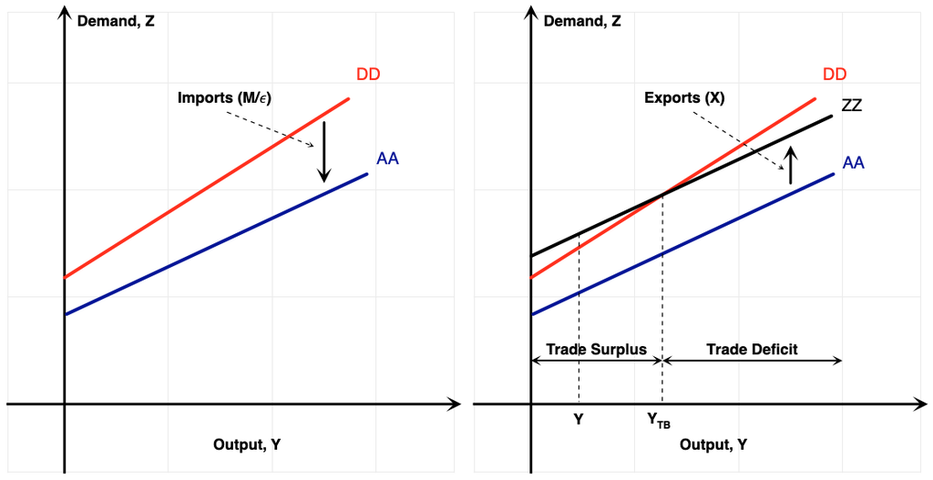

The Keynesian Cross in the Open Economy

# Comparative statics

We are now in a positio to ask how demand affects output in an open economy. We start with an increase in government spending, and then turn to the effects of an increase in foreign demand.

Increase in government spending. What happens when we have an increase in government spending $\Delta G$? Then we have an effect on output that is given by:
$$\Delta Y=\frac{\Delta G}{1-\left(c_{1}+b_{1}-m_{1}\right)}<\frac{\Delta G}{1-\left(c_{1}+b_{1}\right)}.$$

In this situation, there is an effect on the trade balance. The effect on exports is zero, since foreign output does not change by assumption – however, note that if the foreign country’s GDP also depends on the home GDP, then foreign output might change as well, and this may also boost exports – this is what Keynes (1936) suggested in the above quote when he stated that: “On the other hand our own country may recover a portion of this leakage through favourable repercussions due to the action of the multiplier in the foreign country in increasing its economic activity.”.

Therefore, the effect on exports is:
$$\Delta X=0.$$

The effect on imports is given by:
$$\Delta\left(\frac{IM}{\epsilon}\right)=m_{1}\Delta Y=\frac{m_{1}}{1-\left(c_{1}+b_{1}-m_{1}\right)}\Delta G.$$

Finally, the effect on the trade balance is:
$$\Delta\left(X-\frac{IM}{\epsilon}\right)=-\frac{m_{1}}{1-\left(c_{1}+b_{1}-m_{1}\right)}\Delta G.$$

This effect is greater, the greater the openness ratio $m_{1}$. Therefore, in countries where the openness ratio is higher, this “leakage” of demand is more severe.

Increase in foreign demand. What happens if there is an increase in foreign demand, that is, an increase in $Y^{*}$. This could be due to an increase in foreign government spending, $G^{*}$, for example. One can forever think of the United States being the foreign country, and Germany, Japan or China being the home country. What would then happen to these countries’ GDP and trade balance?

**The need for international coordination.** Countries prefer to run trade surpluses rather than trade deficits. There are many reasons for this: aversion to foreign debt, risks of losing one’s manufacturing base (cf. Donald Trump), etc. Therefore, there needs to be international coordination, as all countries would like other countries to increase their government spending, but do not want to increase their own.